# EDA_Date

Robert Ramirez

3/20/2021

```r
library(tidyverse)
library(knitr)
library(kableExtra)
library(ggrepel)
#read in data
d = read.csv("final_data.csv")# Next time remove row names when writing CSV
```

# Quick Intro

The main objectives behind this little project is to get used to working with RMarkdown, GIT, muiltivariable regression, nflfastR package, and the overall data science project building phase. I cleaned and accessed the data for this project in a separate R script called data_collecting_cleaning.R. I followed closely to the variables used in the book call {Mathletics](http://stavochka.com/files/Mathletics.pdf) in the *WHAT MAKES NFL TEAMS WIN?* chapter. I will point out that the authors ran this similar model with data from 2003 to 2006. In my model, I used data from 2018 to 2020. This RMarkdown has some Exploratory Data Analysis but mostly related to regression.

| Variables |  |
| --- | --- |
| PY_A | Passing Yard per Attempt |
| DPY_A | Defense-Passing Yards per Attempt |
| RY_A | Rushing Yards per Attempt |
| DRY_A | Defense-Rushing Yards per Attempt |
| TO | Turnovers Committed on Offense |
| DTO | Defensive Turnovers |
| RET_TD | Return TDs by Opponent(includes TDs scored on fumbles, interceptions, kickoffs, and punts) |

## Quicklook of the Data

```r
summary(d) %>% kbl() %>% kable_classic(full_width=F)
```

|  | X | SEASON | TEAM | MARGIN | PY_A | DPY_A | RY_A | DRY_A | TO | DTO | RET_TD |
| --- | --- | --- | --- | --- | --- | --- | --- | --- | --- | --- | --- |
|  | Min. : 1.00 | Min. :2018 | Length:96 | Min. :-214.0 | Min. :4.600 | Min. :4.800 | Min. :3.300 | Min. :3.300 | Min. : 7.00 | Min. : 7.00 | Min. :0.000 |
|  | 1st Qu.:24.75 | 1st Qu.:2018 | Class :character | 1st Qu.: -78.5 | 1st Qu.:5.700 | 1st Qu.:5.900 | 1st Qu.:4.100 | 1st Qu.:4.100 | 1st Qu.:16.75 | 1st Qu.:17.00 | 1st Qu.:1.000 |
|  | Median :48.50 | Median :2019 | Mode :character | Median : -10.0 | Median :6.400 | Median :6.400 | Median :4.300 | Median :4.400 | Median :20.00 | Median :20.00 | Median :2.000 |
|  | Mean :48.50 | Mean :2019 | NA | Mean : 0.0 | Mean :6.353 | Mean :6.366 | Mean :4.353 | Mean :4.361 | Mean :20.61 | Mean :20.61 | Mean :2.521 |
|  | 3rd Qu.:72.25 | 3rd Qu.:2020 | NA | 3rd Qu.: 86.5 | 3rd Qu.:7.000 | 3rd Qu.:6.800 | 3rd Qu.:4.700 | 3rd Qu.:4.700 | 3rd Qu.:24.00 | 3rd Qu.:24.00 | 3rd Qu.:4.000 |
|  | Max. :96.00 | Max. :2020 | NA | Max. : 249.0 | Max. :8.100 | Max. :7.800 | Max. :5.500 | Max. :5.200 | Max. :40.00 | Max. :37.00 | Max. :9.000 |

## Distrubtion

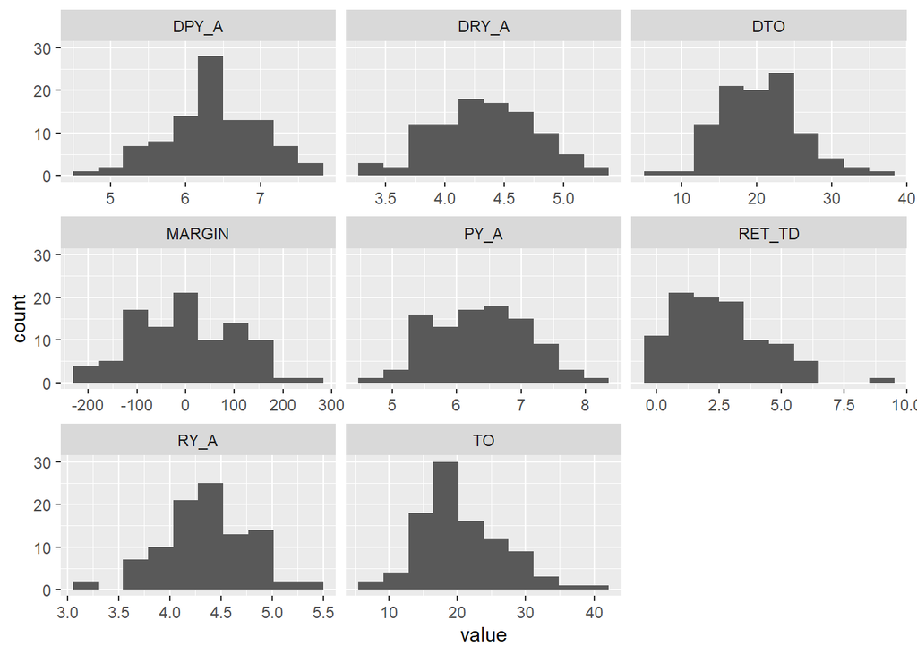

```r
d %>% select(-c(X,SEASON,TEAM)) %>%
  pivot_longer(cols = everything()) %>%
ggplot(aes(value)) +
    geom_histogram(bins = 10)+
  facet_wrap(~name, scales = 'free_x')
```

### Checking the distributions

Looks to have a close normal distribution. RET_TD may be slightly right-tailed which is understandable.

## Quick Pivot Tables

### Offensive Turnovers

```r
pivot_wider(data = d,id_cols = TEAM,names_from = SEASON,values_from = TO) %>% mutate(sum = rowSums(across(where(is.numeric))), mean=rowMeans(across(c("2018","2019","2020"))),across(.cols = mean,.fns = round,1)) %>% arrange(-sum)
```

```
## # A tibble: 32 x 6
##    TEAM  `2018` `2019` `2020`   sum  mean
##    <chr>  <int>  <int>  <int> <dbl> <dbl>
##  1 TB        35     40     16    91  30.3
##  2 SF        30     22     27    79  26.3
##  3 CAR       20     32     21    73  24.3
##  4 PIT       26     30     16    72  24
##  5 NYG       17     33     21    71  23.7
##  6 PHI       22     20     29    71  23.7
##  7 JAX       28     18     24    70  23.3
##  8 BUF       30     19     20    69  23
##  9 NYJ       28     22     19    69  23
## 10 DEN       20     16     32    68  22.7
## # ... with 22 more rows
```

**Just a couple of quick notes on this.** Tampa Bay gets skewed toward a higher sum of turnovers the last three years because of the Jameis Winston effect. He threw for 30 interceptions in 2019 [Jameis Winston](https://www.youtube.com/watch?v=DhfpQcL1ETc).When Tom Brady took over, the offense produced way less turnovers. In 2018, the 49ers went through a carousel of Qbs when Jimmy Garoppolo went down which might have lead to the large amount of turnovers. Be interesting to come back to this to split these to have kept interceptions and fumbles.

Aaron Rodgers is extra careful with the ball hence why Green Bay is at last for turnovers.

### Returned Touchdowns

```r
pivot_wider(data = d,id_cols = TEAM,names_from = SEASON,values_from = RET_TD)%>% mutate(sum = rowSums(across(where(is.numeric)))) %>% arrange(-sum)
```

```
## # A tibble: 32 x 5
##    TEAM  `2018` `2019` `2020`   sum
##    <chr>  <int>  <int>  <int> <dbl>
##  1 NE         4      9      3    16
##  2 BAL        4      6      4    14
##  3 KC         5      4      4    13
##  4 LA         5      3      4    12
##  5 NYJ        5      5      1    11
##  6 CHI        6      2      2    10
##  7 MIA        5      2      3    10
##  8 NYG        5      3      2    10
##  9 PIT        3      4      3    10
## 10 IND        0      3      6     9
## # ... with 22 more rows
```

**Just a point here.** New England had a historic season in 2019 on defense and special teams. Nine returned touchdowns which helped a lot of fantasy players (and hurt other players). To further look into this, let’s look at defensive turnovers. If I remember correctly, Pittsburgh also had a great defense that year.

### Defensive Turnovers

```r
pivot_wider(data = d,id_cols = TEAM,names_from = SEASON,values_from = DTO) %>% mutate(sum = rowSums(across(where(is.numeric))),mean=rowMeans(across(c("2018","2019","2020"))), across(.cols = mean,.fns = round,1)) %>% arrange(-sum)
```

```
## # A tibble: 32 x 6
##    TEAM  `2018` `2019` `2020`   sum  mean
##    <chr>  <int>  <int>  <int> <dbl> <dbl>
##  1 NE        28     33     22    83  27.7
##  2 PIT       14     37     26    77  25.7
##  3 BUF       26     22     26    74  24.7
##  4 LA        29     23     22    74  24.7
##  5 SEA       24     29     21    74  24.7
##  6 CLE       31     20     21    72  24
##  7 IND       25     22     24    71  23.7
##  8 CHI       35     19     16    70  23.3
##  9 KC        26     22     22    70  23.3
## 10 MIA       26     16     28    70  23.3
## # ... with 22 more rows
```

So here, both Pittsburgh and New England had a large amount of turnovers in 2019.

## Correlation

With no categorical variables, just going to go ahead and take a quick look at the correlation of my continuous variables. Just making those quick pivot tables give me a few more ideas for a later projects but I am going to stick to running the regression model.

### Independant Variable Pair Plots

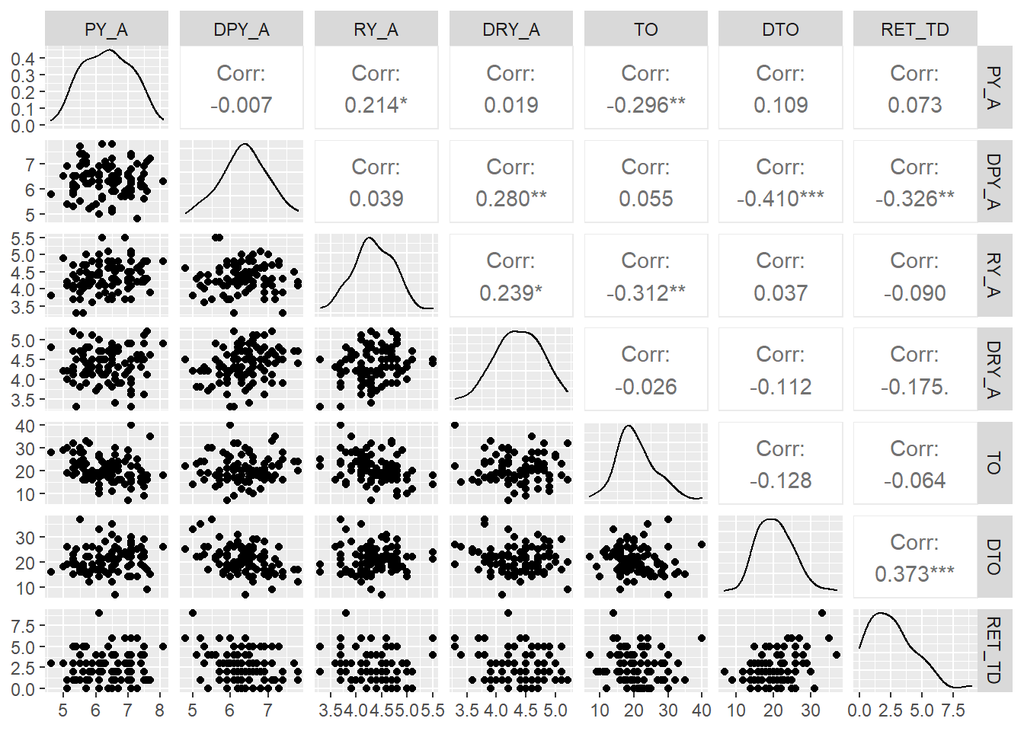

```r
library(GGally)
ggpairs(d[,5:11],)
```

There isn’t much correlation between variables. The strongest one is between Defensive Turnovers(DTO) and Defensive Pass Yards per Attempt(DPY_A) at -0.410 which is still below .50 absolute value. Something to keep in mind when running this model.

## Linear Regression

```r
fit <- lm(MARGIN~PY_A+ DPY_A+RY_A+DRY_A+TO+DTO+RET_TD, data = d)
summary(fit)
```

```
##
## Call:
## lm(formula = MARGIN ~ PY_A + DPY_A + RY_A + DRY_A + TO + DTO +
##     RET_TD, data = d)
##
## Residuals:
##     Min      1Q  Median      3Q     Max
## -94.964 -25.474  -2.702  26.704  91.363
##
## Coefficients:
##             Estimate Std. Error t value Pr(>|t|)
## (Intercept)  19.3297    86.0427   0.225  0.82277
## PY_A         65.3632     5.9143  11.052  < 2e-16 ***
## DPY_A       -66.6124     7.5839  -8.783 1.15e-13 ***
## RY_A         30.3292    10.8010   2.808  0.00614 **
## DRY_A       -31.2972    10.5881  -2.956  0.00400 **
## TO           -4.4716     0.7792  -5.739 1.33e-07 ***
## DTO           3.6549     0.9022   4.051  0.00011 ***
## RET_TD        4.2647     2.5721   1.658  0.10087
## ---
## Signif. codes:  0 '***' 0.001 '**' 0.01 '*' 0.05 '.' 0.1 ' ' 1
##
## Residual standard error: 40.55 on 88 degrees of freedom
## Multiple R-squared:  0.8503, Adjusted R-squared:  0.8384
## F-statistic: 71.43 on 7 and 88 DF,  p-value: < 2.2e-16
```

## Takeaways

Based off of the results. Our model explains 84 percent of the variability. In our residuals, we have a Median of -2.702 which is relatively close to 0. The Max and Min are closely similar as well.

These results are closely similar to the model ran in Mathletics except for the significance of Returned Touchdowns (RET_TD). In this model, it is not as significant as in their model. Their P Value is 0.014520952 as opposed to 0.10087. The difference here could possibly be attributed to rule changes regarding kick-off returns. During their study, there may have been more kick-offs returned than there are today.

But on that note something that puzzles me is that the league has gone to a more pass first opposed to running. So wouldn’t there be more interceptions returned for touchdowns in recent years? So to me that may still be somewhat significant. Turnovers on both sides of the ball are weighed about the same which is understandable that a team win the turnover battle. But it appears that for this model offensive turnovers (TO) are much more significant. I think I’d like to explore this a bit more moving forward.